# BANA_610_Project

## **Exploring Sleeping Patterns Across Lifestyles**

The essence of our well-being is strongly linked to sleep. As we continue to navigate the different stages of our lives, we expereince shifts in our professional life and adopt diverse lifestyles, however the significance of our sleep remains. Today, we will have the opportunity to expore sleeping patterns across a variety of factors.

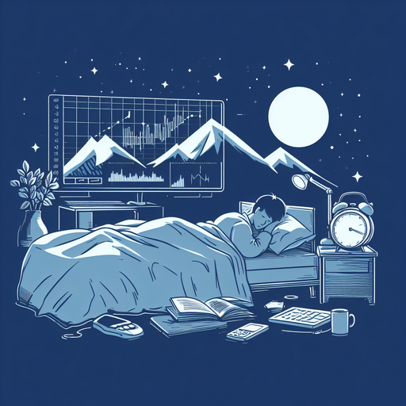

## **What is healthy sleep, and why is it important to have it?**

Healthy sleep refers to getting sufficient sleep duration as well as high sleep quality. Healthy sleep requires adequate sleep duration, appropriate timing, regularity, the absence of sleep disorders, and good quality.

The National Sleep Foundation recommends 7-9 hours of sleep per night for adults. [2]

Healthy sleep is important for cognitive functioning, mood, mental health, and cardiovascular, cerebrovascular, and metabolic health.[3]

## **Let's first discover the dataset's attributes and if the genders are equally represented.**

```python
import pandas as pd
import matplotlib.pyplot as plt
import seaborn as sns
import numpy as np
df = pd.read_csv('Sleep_health_and_lifestyle_dataset.csv')
df.head()
```

|  | Person ID | Gender | Age | Occupation | Sleep Duration | Quality of Sleep | Physical Activity Level | Stress Level | BMI Category | Blood Pressure | Heart Rate | Daily Steps | Sleep Disorder |
| --- | --- | --- | --- | --- | --- | --- | --- | --- | --- | --- | --- | --- | --- |
| 0 | 1 | Male | 27 | Software Engineer | 6.1 | 6 | 42 | 6 | Overweight | 126/83 | 77 | 4200 | None |
| 1 | 2 | Male | 28 | Doctor | 6.2 | 6 | 60 | 8 | Normal | 125/80 | 75 | 10000 | None |
| 2 | 3 | Male | 28 | Doctor | 6.2 | 6 | 60 | 8 | Normal | 125/80 | 75 | 10000 | None |
| 3 | 4 | Male | 28 | Sales Representative | 5.9 | 4 | 30 | 8 | Obese | 140/90 | 85 | 3000 | Sleep Apnea |
| 4 | 5 | Male | 28 | Sales Representative | 5.9 | 4 | 30 | 8 | Obese | 140/90 | 85 | 3000 | Sleep Apnea |

## **Dataset Features**

1. Person ID: An identifier for each individual.
2. Gender: The gender of the person (Male/Female).
3. Age: The age of the person in years.
4. Occupation: The occupation or profession of the person.
5. Sleep Duration (hours): The number of hours the person sleeps per day.
6. Quality of Sleep (scale: 1-10): A subjective rating of the quality of sleep, ranging from 1 to 10.
7. Physical Activity Level (minutes/day): The number of minutes the person engages in physical activity daily.
8. Stress Level (scale: 1-10): A subjective rating of the stress level experienced by the person, ranging from 1 to 10.
9. BMI Category: The BMI category of the person (e.g., Underweight, Normal, Overweight).
10. Blood Pressure (systolic/diastolic): The blood pressure measurement of the person, indicated as systolic pressure over diastolic pressure.
11. Heart Rate (bpm): The resting heart rate of the person in beats per minute.
12. Daily Steps: The number of steps the person takes per day.
13. Sleep Disorder: The presence or absence of a sleep disorder in the person (None, Insomnia, Sleep Apnea).

```python
df.shape
```

```
(374, 13)
```

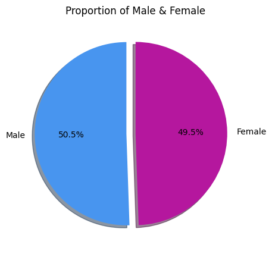

```python
names = df['Gender'].value_counts().index.tolist()
names
values = df['Gender'].value_counts().tolist()
values
colors = ['#4895ef', '#b5179e']
explode = (0.1, 0)

fig = plt.figure(figsize=(5, 5))
plt.pie(values, labels=names, colors=colors, autopct='%1.1f%%', startangle=90, explode=explode, shadow=True)
plt.title('Proportion of Male & Female')
plt.show()
```

Examining the visualization, it becomes evident that both genders, male and female, are nearly equally represented in the data.

Let's start by looking how sleep duration is distributed across genders.

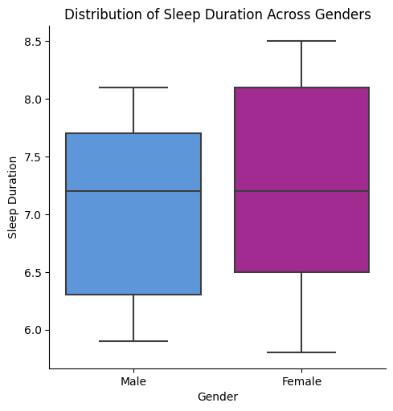

```python
sns.catplot(data=df, x='Gender', y='Sleep Duration', kind='box', palette={'Male':'#4895ef','Female':'#b5179e'})
plt.title('Distribution of Sleep Duration Across Genders')
plt.show()
```

The box plot shows that Females tend to have a longer sleep duration than Males.

Let's check which occupation gets the most sleep.

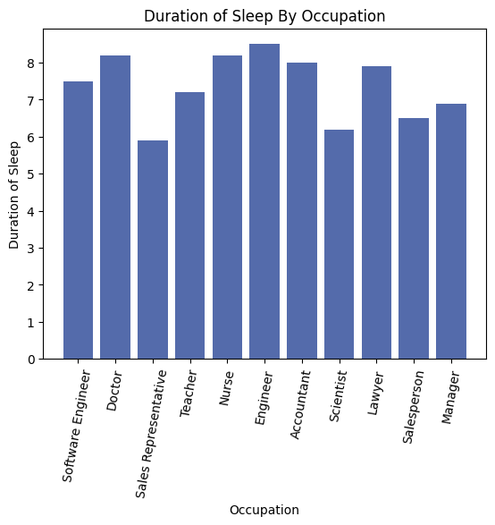

```python
data = pd.read_csv('Sleep_health_and_lifestyle_dataset.csv')
df = pd.DataFrame(data)
X = list(df.iloc[:, 3])
Y = list(df.iloc[:, 4])
plt.bar(X, Y, color='#546bab')
plt.title("Duration of Sleep By Occupation")
plt.xticks(rotation = 80)
plt.xlabel("Occupation")
plt.ylabel("Duration of Sleep")
plt.show()
```

Looking at the Graph above, the occupation that gets the most sleep is Enigneering.

The second biggest group that has the most sleep is Doctor, followed by Nurses, Accountants and so on. The implication here is that Engineers face less levels of stress allowing them to have longer durations of sleep and even better quality as well.

Let us analyse wheteher quality of sleep is affected by stress.

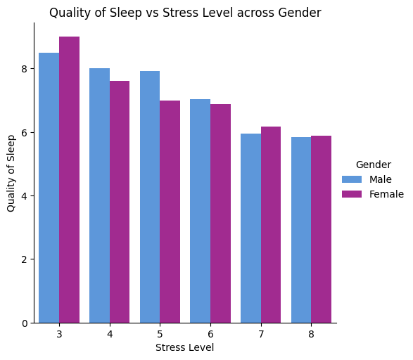

```python
sns.catplot(data=df , y='Quality of Sleep', x= 'Stress Level',kind='bar', hue='Gender',errorbar=None,
             palette={'Male':'#4895ef','Female':'#b5179e'})
plt.title("Quality of Sleep vs Stress Level across Gender" )
plt.xlabel("Stress Level")
plt.ylabel("Quality of Sleep")
plt.show()
```

We can see that sleep quality is inversely proportional to stress.

At lower stress levels, sleep quality ratings appear relatively consistent. However, as stress level rises, there's a noticeable decline in sleep quality.

Let's check how the number of daily steps affect the sleep quality.

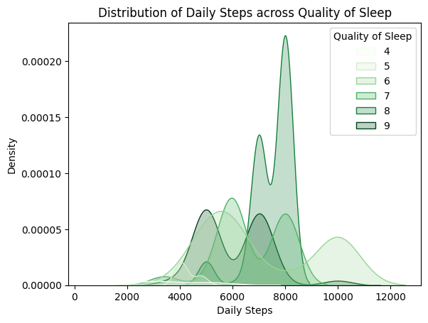

```python
sns.kdeplot(data=df, x = 'Daily Steps',  hue='Quality of Sleep',fill=True, palette='Greens')
plt.title('Distribution of Daily Steps across Quality of Sleep')
plt.show()
```

Let's analyse the relationship between blood pressure and quality of sleep.

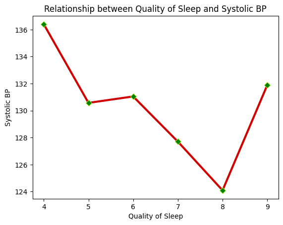

```python
df['Systolic BP'] = df['Blood Pressure'].str.extract('(\d+)/\d+')
df['Systolic BP'] = df['Systolic BP'].astype(int)
df = df.sort_values(by='Systolic BP')
sns.lineplot(data=df, x='Quality of Sleep', y='Systolic BP', errorbar=None, linewidth=3, color='#D00000', marker='D',markersize=6,
              mfc='#008000', mec='#9ef01a')
plt.title('Relationship between Quality of Sleep and Systolic BP');
```

```python
df['Sleep Disorder'].value_counts()
```

```
None           219
Sleep Apnea     78
Insomnia        77
Name: Sleep Disorder, dtype: int64
```

```python
# define 2d contingency_table
contingency_table = pd.crosstab(df['BMI Category'], df['Sleep Disorder'])
contingency_table
```

| Sleep Disorder BMI Category | Insomnia | None | Sleep Apnea |
| --- | --- | --- | --- |
| Normal | 7 | 183 | 5 |
| Normal Weight | 2 | 17 | 2 |
| Obese | 4 | 0 | 6 |
| Overweight | 64 | 19 | 65 |

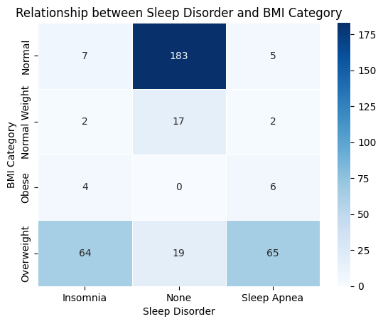

```python
sns.heatmap(contingency_table, cmap='Blues', annot=True, fmt='d', linewidths=0.5)
plt.title('Relationship between Sleep Disorder and BMI Category')
plt.show()
```

The above map shows that the majority of people with Normal as well as Normal weight category have no sleep disorder. Similarly majority of the people who are Obese and Overweight have Insomnia and Sleep Apnea. Overall, the map shows the existence of a correlation between Sleep Disorder and BMI Category.

## **Let's understand how sleep duration is correlated with age,gender and quality of sleep**

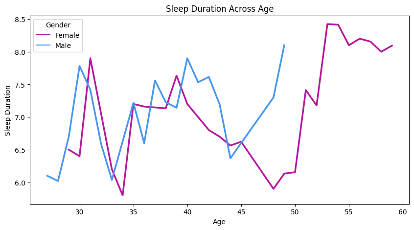

```python
plt.figure(figsize=(10,5))
sns.lineplot(data=df, x='Age', y='Sleep Duration', hue='Gender', palette={'Male':'#4895ef', 'Female':'#b5179e'}, errorbar=None, linewidth=2.5)
plt.title('Sleep Duration Across Age')
plt.xlabel('Age')
plt.ylabel('Sleep Duration')
plt.show()
```

The lineplot shows that with an increase in age, the sleep duration also increases. There is a difference in sleep duration and age based on gender.

The visualization shows similar trend patterns between men and women in ages between 30-45. Given the visualization, women had a decline in sleep duration between the age of 45 and 50. Consequently, the sleep duration continues to increase past the age of 50.

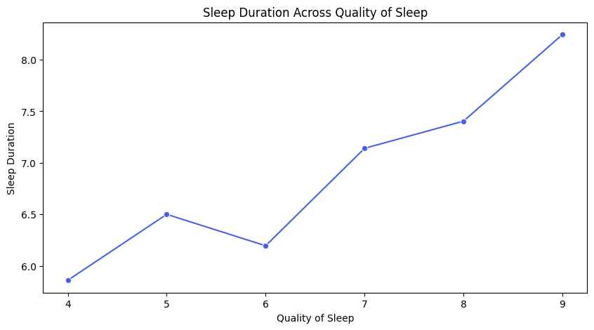

```python
plt.figure(figsize=(10,5))
sns.lineplot(data=df, x='Quality of Sleep', y='Sleep Duration', color='#4361ee', marker='o', errorbar=None)
plt.title('Sleep Duration Across Quality of Sleep')
plt.xlabel('Quality of Sleep')
plt.ylabel('Sleep Duration')
plt.show()
```

The visualization above showcases the relationship between sleep duration and quality of sleep. From the above graph, we can quickly identify a pattern, as sleep duration increases, the quality of sleep in individuals also increases.

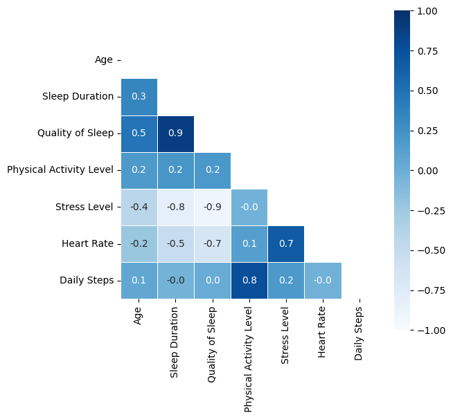

```python
new_df = df.iloc[:, 2:13]
tri_matrix = 1 - np.tri(new_df.corr(numeric_only=True).shape[0], k=-1)

plt.figure(figsize=(6, 6))
sns.heatmap(new_df.corr(numeric_only=True), cmap='Blues', linewidths=0.5, square=True,
            mask=tri_matrix,vmin=-1,vmax=1, annot=True, fmt='.1f')
plt.show()
```

## **Conclusion**

**Additionally, the prevalence of sleep disorders seems to correlate with BMI status - overweight and obese individuals are more likely to have conditions like insomnia and sleep apnea compared to those with normal BMI.**

## **References**

1. Sleep,Health and Lifestyle Dataset -https://www.kaggle.com/datasets/uom190346a/sleep-health-and-lifestyle-dataset
2. National Sleep Foundation's updated sleep duration recommendations: https://pubmed.ncbi.nlm.nih.gov/29073398/
3. Sleep is essential to health: an American Academy of Sleep Medicine position statement: https://doi.org/10.5664/jcsm.9476